# S9_Informe

Christian

03/08/2021

## Índice

1. Introducción
2. Objetivos
3. Marco Teórico
4. Descriptores Numéricos y Gráficos
5. Estudio de población y mercado
6. Variables aleatorias
7. Representatividad de la muestra
8. PLanteamiento y pruebas de hipótesis
9. Regresión
10. Conclusión

## 1. Introducción

##### **Importancia**

Consideramos que el tema es relevante debido a que un **estudio de mercado** que refleje las preferencias de los productos de fanáticos del género **K-pop** aportará ideas para el entendimiento del mercado relacionado a este género musical. Nuestro estudio permitirá recomendar a los nuevos emprendimientos o tiendas sobre los productos y servicios que se podrían lanzar al mercado. Para ello, lo primero que se realizará será analizar a la población seguidorá del K-pop, para así reconocer sus características y preferencias. Finalmente, podemos decir que este proyecto es de interés para los nuevos emprendimientos y tiendas que deseen ofertar un producto o servicio relaciona al K-pop, puesto que al conocer a la población y sus demandas asegurarán clientes y, por ende, ingresos.

##### **Justificación**

Es **interesante** porque desde la llegada del K-pop al Perú, los fanáticos de este género han ido aumentando a través de los años, la evidencia más clara de interés se puede observar en el Campo de Marte, donde una gran multitud se reúne a practicar coreografías, escuchar canciones de las distintas bandas y en sí compartir más de este género musical. El apogeo del K-pop conlleva a un nuevo mercado asociado a los productos de la cultura asiática, a pesar de esto, aún no se conoce las características de esta población, esta limitación genera que la inserción de un mercado en este entorno sea mucho más complicado, muestra de ello es que solo existe una tienda en todo el país que oferta sus productos, “Kasoo”.

Es **factible** porque la comunidad del K-pop accede y participa frecuentemente en las redes sociales, medio por el cual difundiremos nuestra encuesta. Además, trabajamos con un dataframe que contiene las preferencias de los productos de la comunidad K-pop obtenidas por medio de una encuesta corta a través de google forms.

Es **específico** porque se centra en una sola población la cual es **seguidores del K-pop**, siendo un grupo de fácil alcance.

Es **desconocido** porque no encontramos un **estudio de población** que brinde las **caracteristicas** y **demandas** actuales de este sector, el cual permita realizar la inserción de un producto o servicio al mercado.

A continuación, presentamos un plan que permite llevar a cabo el trabajo en los plazos planteados.

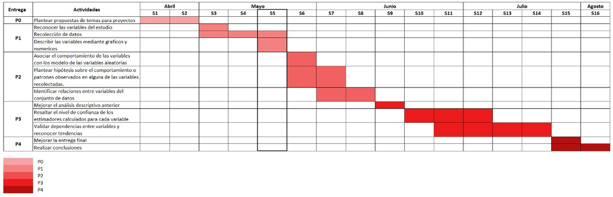

## 2. Objetivos

##### **Objetivo General**

Conocer las características de la población seguidora del K-pop y encontrar las particularidades de su demanda para determinar la mejor opción de emprendimiento que pueda ser lanzado a este mercado.

##### **Objetivo secundarios o preguntas**

- ¿Cuáles son las características de la población seguidora del K-pop en el Perú?
- ¿Cuál es la mejor opción de servicio o producto que un emprendedor puede sacar al mercado para la población seguidora del K-pop?
- ¿Qué características debe tener el producto o servicio para cumplir con la demanda de la población del K-pop?

## 3. Marco Teórico

##### **Población objetivo**

- Comunidad k-POP del Perú

##### **Tipo de muestreo**

- Muestreo por conveniencia

##### **Sesgo**

- Sesgo de selección

##### **Unidades muestrales**

- 192 encuestados

```r
sum(!complete.cases(DF))
```

```
## [1] 44
```

```r
sum(complete.cases(DF))
```

```
## [1] 148
```

##### **Interesados**

- Nuevos emprendimientos
- Distribuidores de productos asiáticos

##### **Obtención de datos**

**Obtención de datos**

La obtención de datos se realizó a través de una encuesta sobre las preferencias y gustos en los productos del mercado K-pop

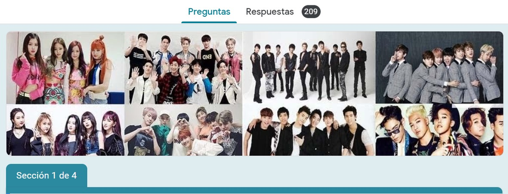

**Limpieza de datos de encuesta**

La limpieza de datos para esta parte consistió en mantener solo a las personas que son seguidoras del K-pop, descartando, mediante la pregunta 1, las demás observaciones.

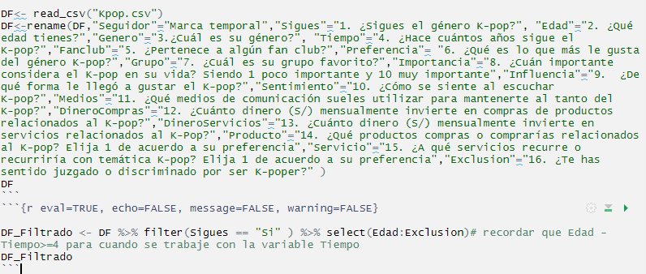

##### **Variables**

**Variables de DataFrames(KP)**

| Pregunta | Variable | Tipo de variable | Restricciones |
| --- | --- | --- | --- |
| ¿Sigues el género K-pop? | Seguidor | Categórica Nominal | Sí y No |
| ¿Qué edad tienes? | Edad | Numérica Discreta | Número entero mayor a 0 |
| ¿Cuál es su sexo? | Gen | Categórica Nominal | Ninguna |
| ¿Desde hace cuántos años sigue el K-Pop? | Seguimiento | Numérica Discreta | Número entero mayor a 0 |
| ¿Qué es lo que más le gusta del género K-Pop? | Gusto_Total | Categórica Nominal | Ninguna |
| ¿Cuál es su grupo favorito? | Grupo | Categórica Nominal | Ninguna |
| ¿Cuán importante considera el K-Pop en su vida? | Importancia | Categórica Ordinal | Número entero entre 1 al 5 |
| ¿De qué forma le llegó a gustar el K-Pop? | Gusto_Inicio | Categórica Nominal | Ninguna |
| ¿Qué sienten al escuchar K-Pop? | Sentimiento | Categórica Nominal | Ninguna |
| ¿Qué medios de comunicación sueles utilizar para informarte del mundo de K-pop? | Medios | Categórica Nominal | Ninguna |
| ¿Cuánto dinero invierte en compras de productos relacionados al K-Pop? | Gasto_Productos | Numérica Continua | Número racional mayor o igual a 0 |
| ¿Cuánto dinero invierte en servicios relacionados al K-Pop? | Gasto_Servicios | Numérica Continua | Número racional mayor o igual a 0 |
| ¿Qué productos compras (comprarías) relacionados al K-Pop? | Tipo_Producto | Categórica Nominal | Ninguna |
| ¿A qué servicios recurre (recurriría) con temática K-Pop? | Tipo_Servicios | Categórica Nominal | Ninguna |
| ¿Te has sentido juzgado o discriminado por ser k-poper? | Discriminacion | Categórica Nominal | Sí y No |

**Variable adicionales a partir del estudio de población (DR)**

| Variable | Tipo de variable | Restricciones |
| --- | --- | --- |
| Recurrencia | Numérica Discreta | Mayor o igual a 0 |
| IMC | Numérica continua | Decimal positivo |
| InverM | Numérica Continua | Mayor o igual a 0 |
| Peso | Numérica Continua | Mayor o igual a 40 |
| Estatura | Numérica Continua | Mayor o igual a 150 |
| T_Comida | Categórica Nominal | Ninguna |
| B_comida | Categórica Nominal | Sí y No |
| Tipo_Dieta | Categórica Nominal | Ninguna |
| Kilocalorias | Numérica Continua | Mayor o igual a 0 |
| OMS_ims | Categórica Nominal | Ninguna |

También se insertó el indice de masa corporal para posterior análisis y esta fue clasificado en grupos de acuerdo a la organización mundial de la salud

Estas variables se agregaron al DataFrame(CR) como parte de un apoyo a la investigación de mercado y la realización del proyecto(Restaurante)

## 4. Descriptores

Primero se realizará el análisis de las variables de la encuesta realizada, esto con el objetivo de conocerlos más y resaltar características importantes

### 4.1 Descriptores númericos

#### 4.1.1. Descriptores númericos población

#### **Edad:**

```
##            Edad
## Min        9
## Max        35
## Moda       19
## Media      18.89
## Mediana    19
## Desviacion 3.3
## Varianza   10.91
## CV         0.17
```

##### **Años que ya llevan siguiendo al grupo**

```
##            Años_fan
## Min        0
## Max        17
## Moda       3
## Media      3.57
## Mediana    3
## Desviacion 2.87
## Varianza   8.22
## CV         0.8
```

#### Observaciones

##### **Inversión disponible para productos y servicios**

```
##            Producto Servicio
## Min        0        0
## Max        400      300
## Moda       0        0
## Media      50.88    29.85
## Mediana    30       10
## Desviacion 68.88    50.76
## Varianza   4744.47  2576.2
## CV         1.35     1.7
```

#### Observaciones

- Moda:Por más que la mayoría de los encuestados demostró sentir una gran admiración por el género estudiado, la mayoría de estas no invierte dinero alguno con respecto al K-pop.
- Mediana: Al menos la mitad de la población gasta 30 soles en productos K-pop y 10 soles en servicios
- Media:Se filtró los datos debido a que el gasto de la mayoria es menor a 500 soles, pero hay una parte que invierte cantidades inmensas, que haría que la media, al no ser robusta, sea mayor a 200 soles.
- Desviación estándar: Esto refleja la dispersión existente entre los datos y la media de los mismo, al tener un valor demasiado grande, se concluye que los datos están muy dispersos, y esto se demuestra con la mayoría de gastos nulos y los gastos muy significativos que tienen los otros.

#### 4.1.1. Descriptores númericos relacionada a la inserción de un restaurante

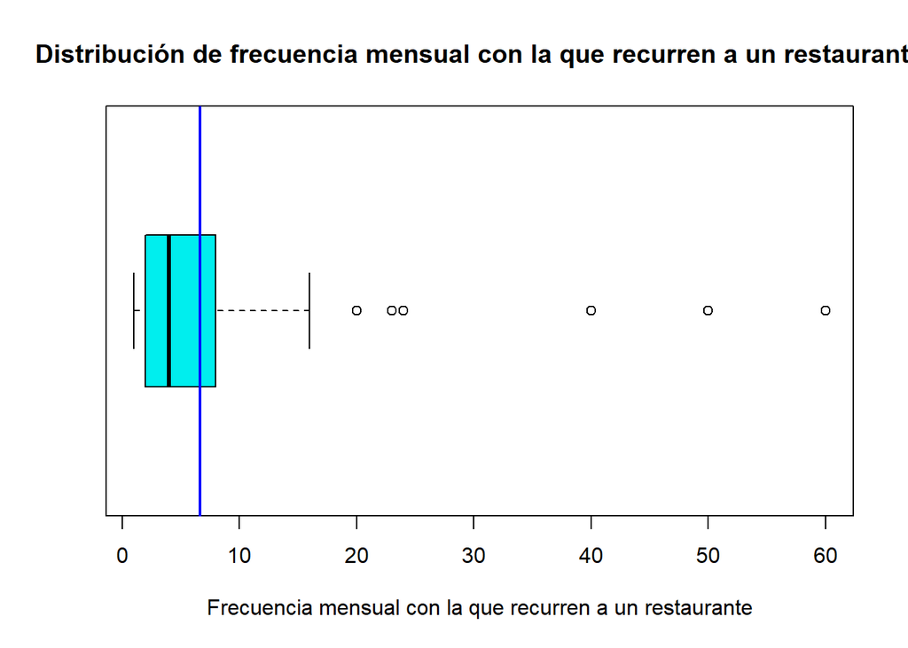

**Observaciones**

- Los valores de la frecuencia con la que recurren a un restaurante presentan un sesgo hacia la derecha.
- Se observa 6 datos atípicos.

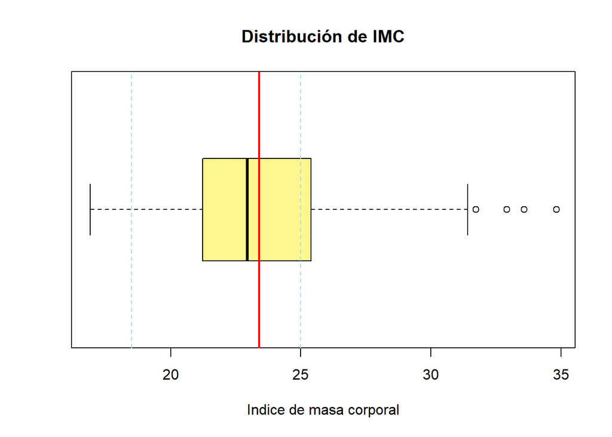

**Observaciones**

- Los valores del IMC presentan un sesgo hacia la derecha.
- Se observa 4 datos atípicos.
- La mayor parte de las personas tienen un IMC adecuada. Sin embargo, hay algunas personas con un IMC alto.

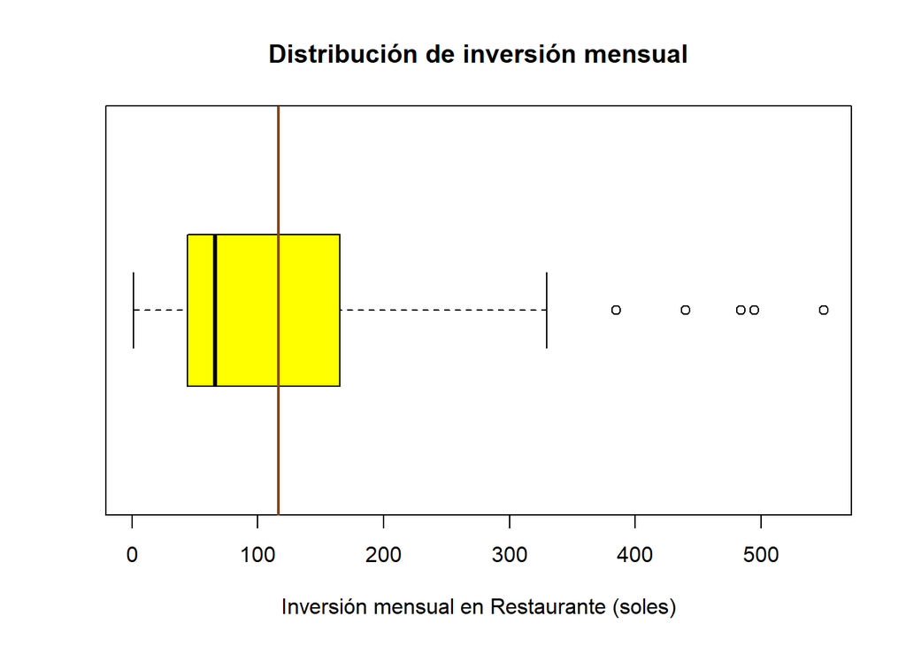

**Observaciones**

- Los valores de inversión mensual en restaurantes están sesgadas hacia la derecha
- Se observa 5 datos atípicos.

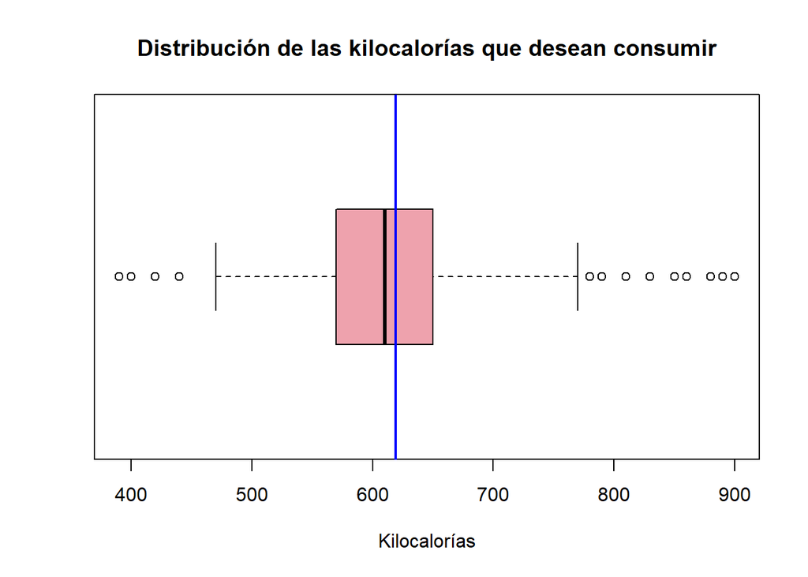

**Observaciones**

- Los valores de Kilocalorías que quieren consumir presentan un sesgo hacia la derecha.
- Se observa 13 datos atípicos.
- Los datos atípicos se encuentra en ambos extremos.

### 4.2 Descriptores categóricos

#### **Género:**

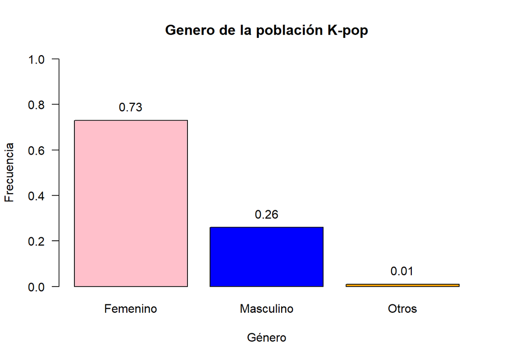

**Observaciones**

- Se puede observar que dentro de la muestra, el genero femenino se encuentra en mayor proporción.

#### **Influencia que le hizo gustar el Kpop:**

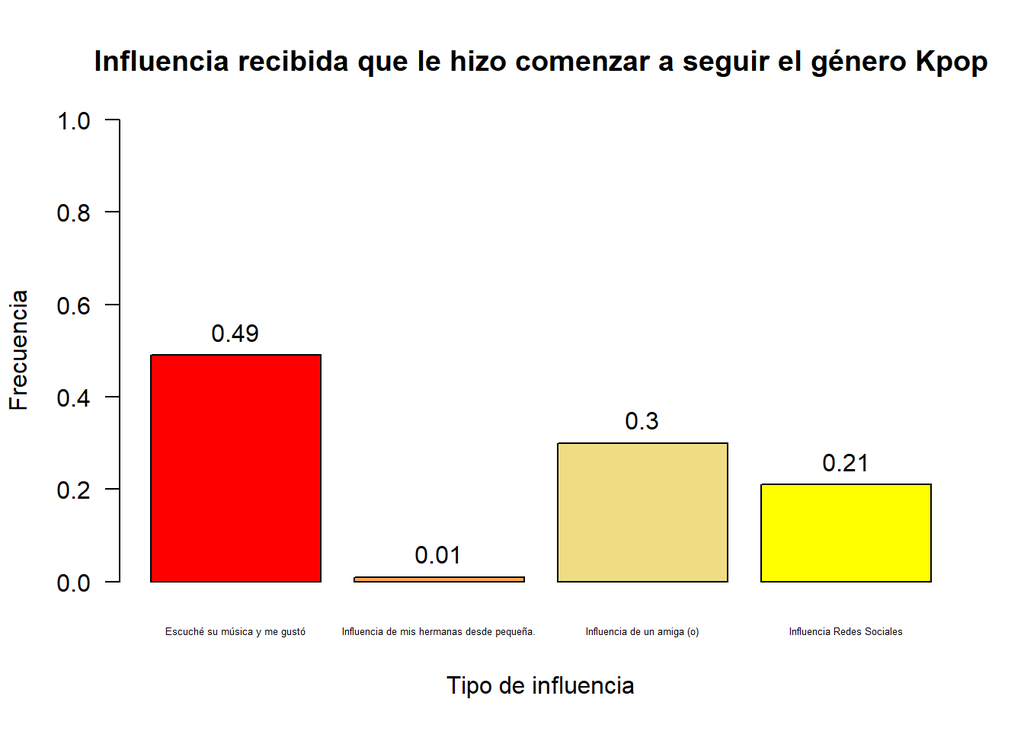

**Observaciones**

##### **Años que ya llevan siguiendo al grupo**

Analisis de la **distribución de años de seguimiento al K-pop** mediante una caja de bigotes:

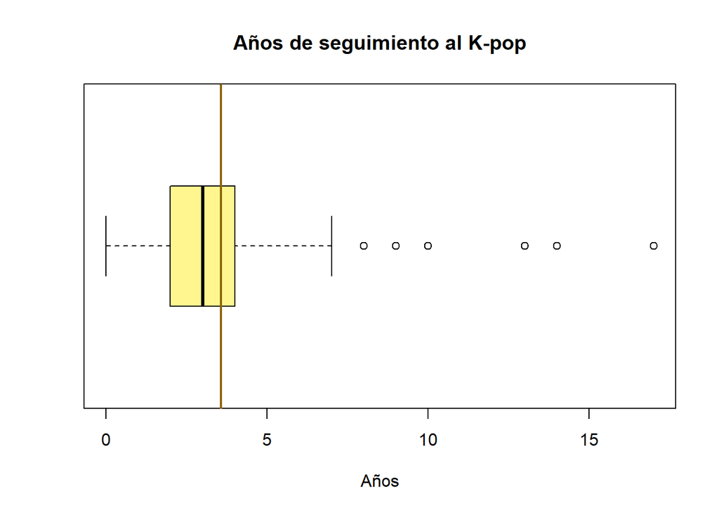

**Observaciones**

#### **Variable Fanclub**

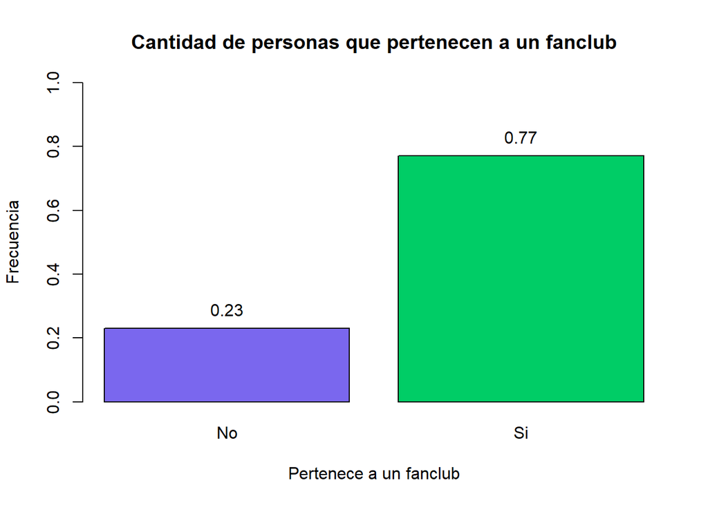

**Observaciones**

- La mayoría de los fanáticos pertenece a un club de fans, lo que nos da pie a poder decir que existe diferentes comunidades en el Perú.
- Aunque casi la cuarta parte de la población no pertenece a un fan club, sus gustos y favoritismo al K-pop hacen que no sea de gran importancia pertenecer a lo mencionado anteriormente.

#### **Variable Preferencia**

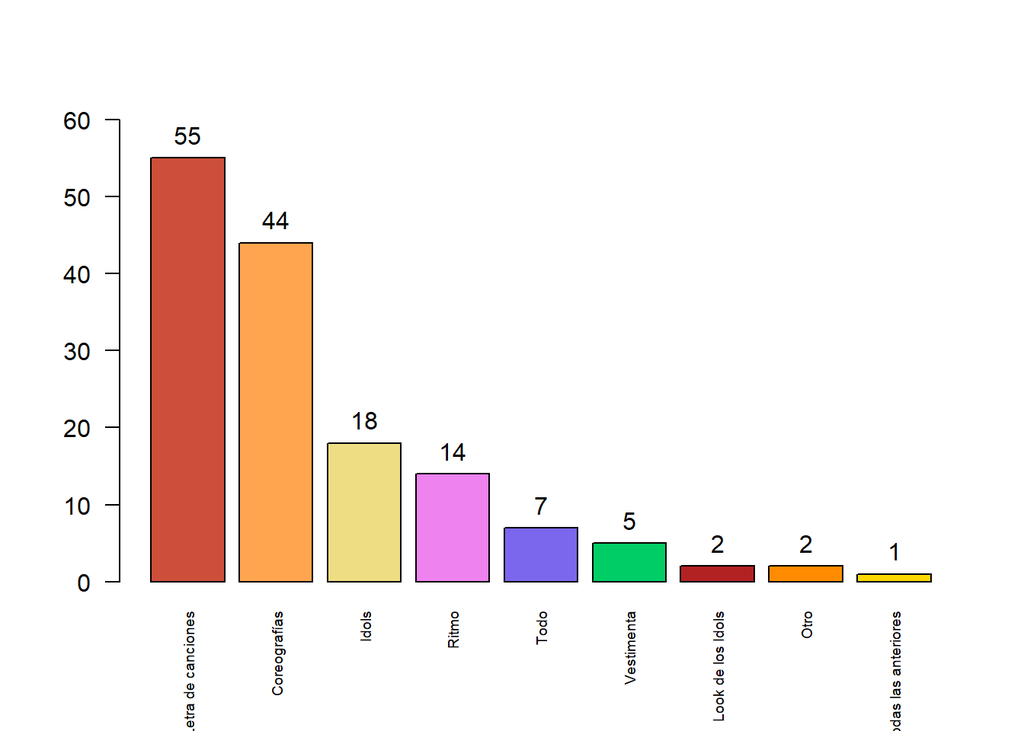

**Observaciones**

- Las letras de las canciones y coreografías del genero k- pop son las preferidas por los fans. Así mismo existe una cantidad de fans que prefieren todas las opciones.
- Tanto el look de los Idols como su vestimenta es menos apreciable para nuestra población.

#### **Variable importancia**

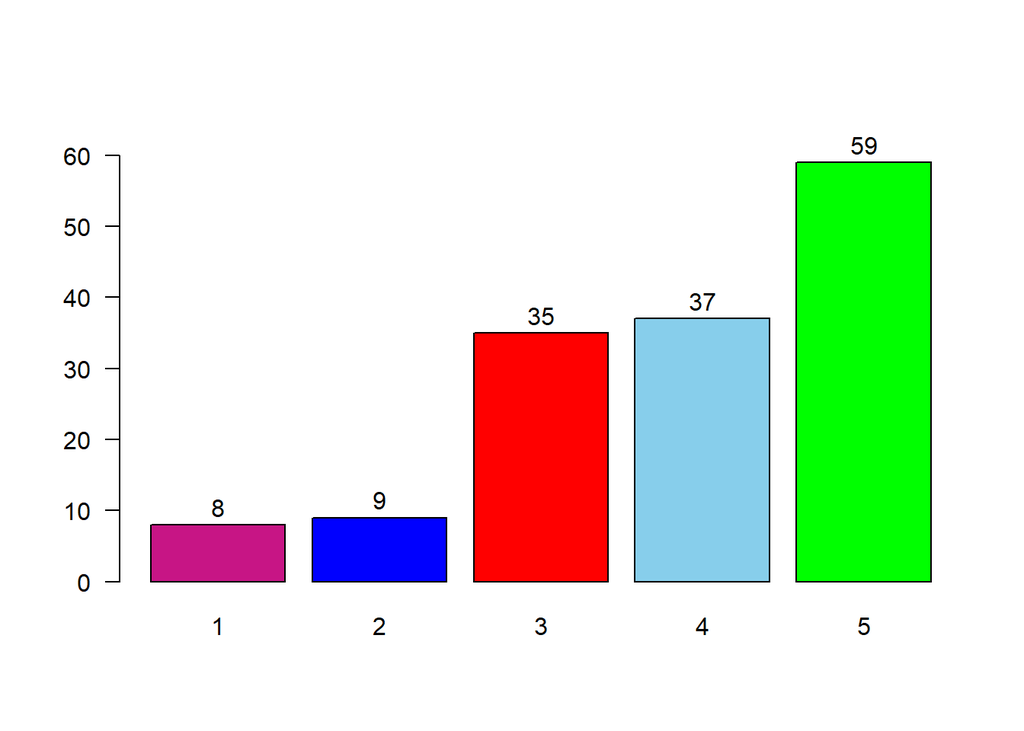

**Observaciones**

##### **Inversión disponible para productos y servicios**

Analisis de la **distribución del dinero que se invierte (invertiría) mensualmente** mediante una caja de bigotes:

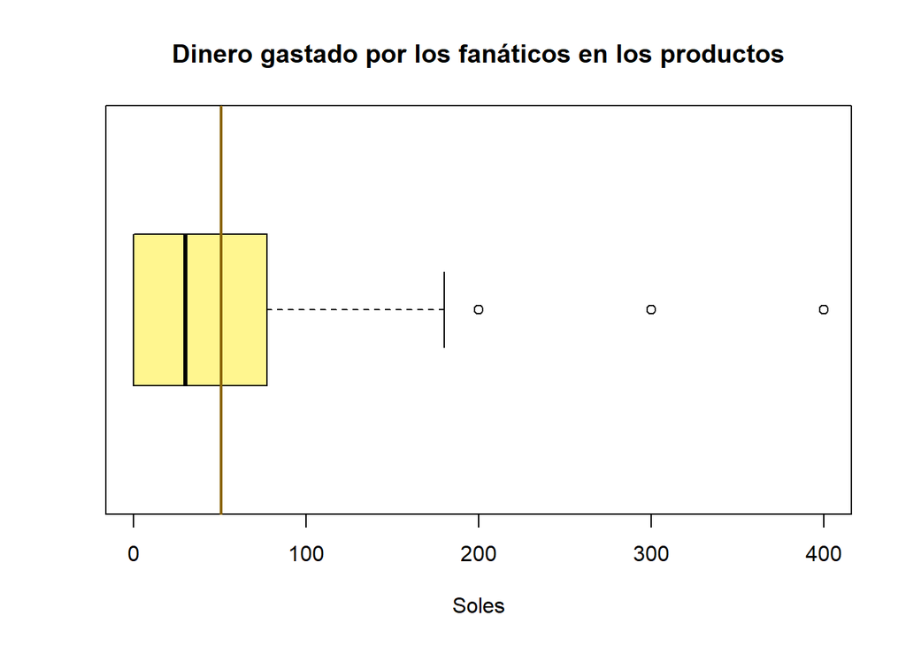

**Observaciones**

- Existen 3 valores atípicos.
- El dinero invertido en productos tiene un sesgo a la derecha.
- Una cantidad considerable de fanáticos no gasta en productos.
- Se filtraron 4 datos que cambian la media considerablemente, pero se tiene en cuenta que existen personas que invierten un dinero muy elevado en productos en comparación al resto.

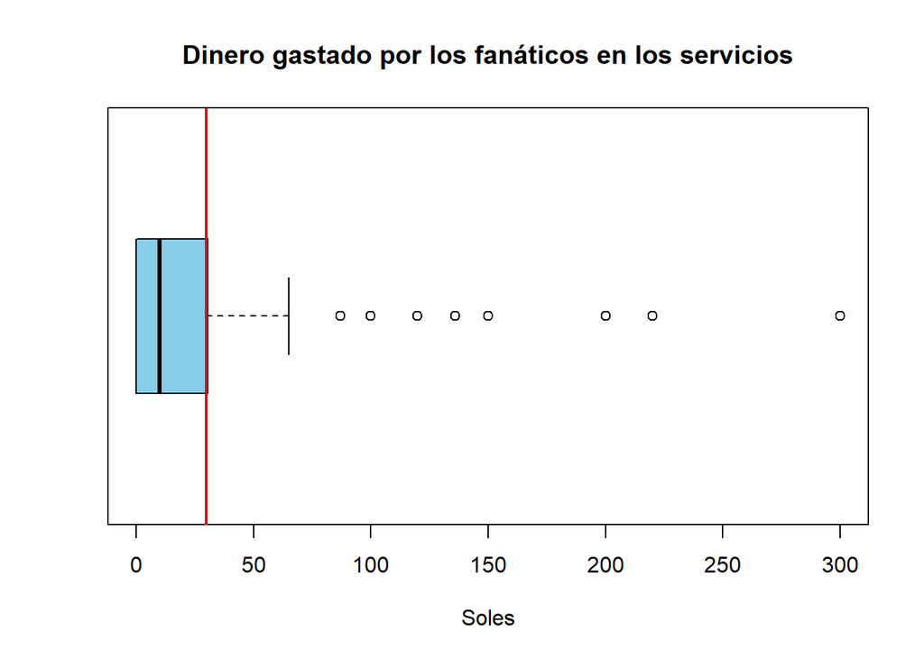

**Observaciones**

- Existen 8 valores atípicos.
- Una cantidad considerable de fanáticos no gasta en servicios.
- Se filtraron 4 datos que cambian la media considerablemente, pero se tiene en cuenta que existen personas que invierten un dinero muy elavado en servicios en comparación al resto.

## 5. Estudio de población y mercado

### 5.1. ¿Qué características tiene la población seguidora del k-pop?

**Correlación entre el género y banda de Kpop**

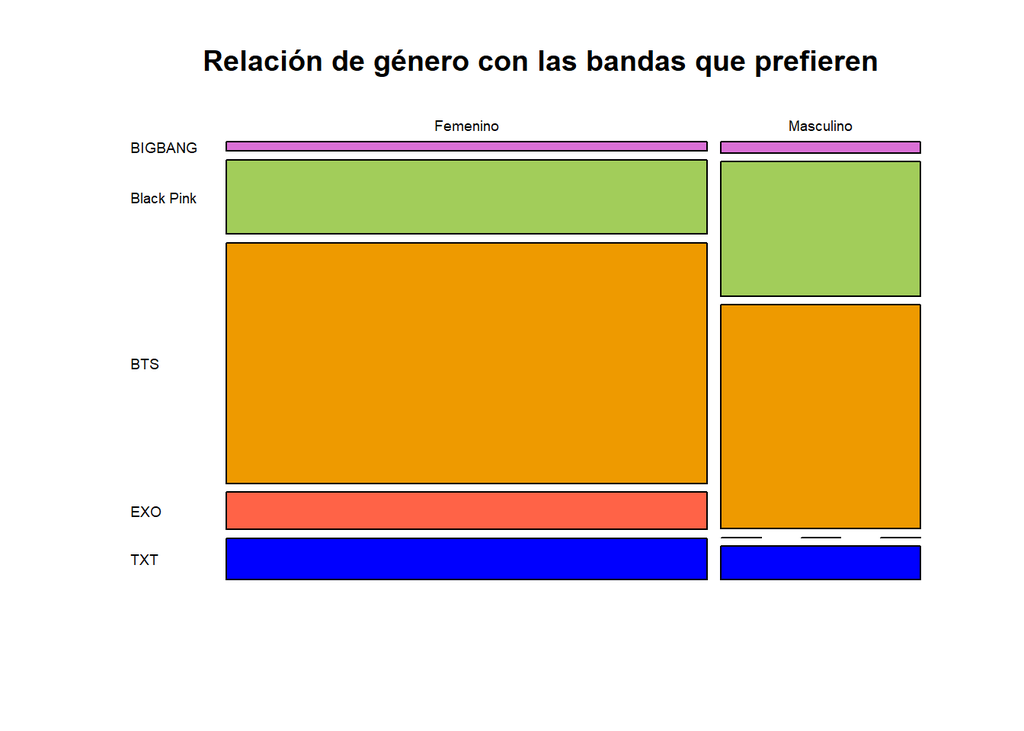

**Observaciones**

**Importancia del K-pop dependiendo del género**

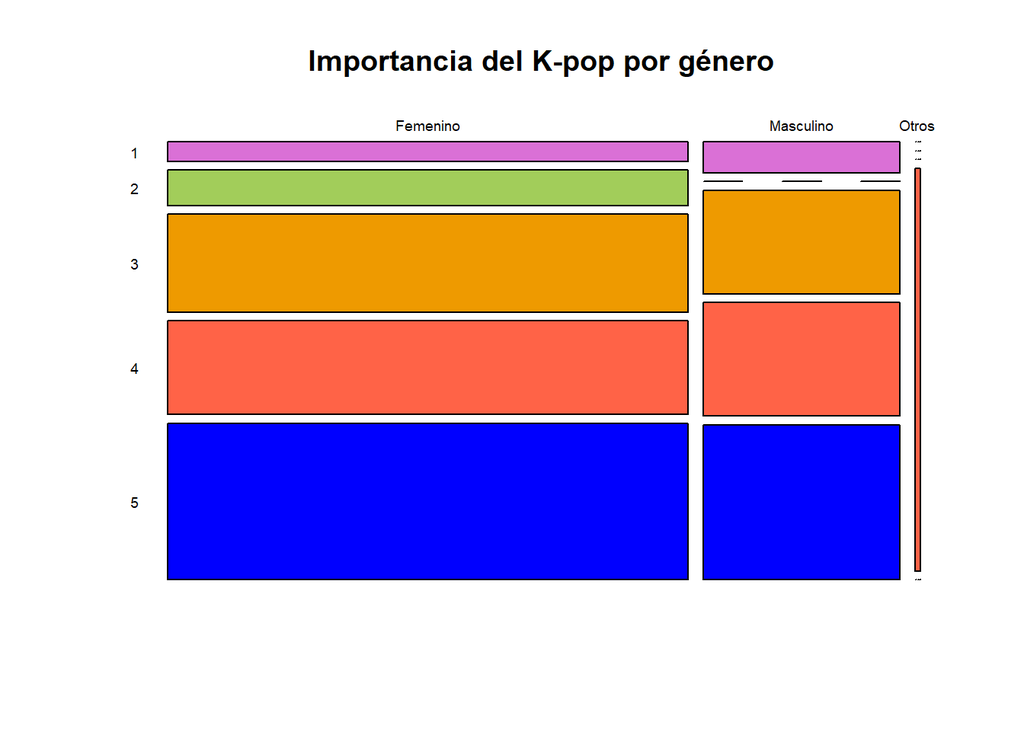

**Observaciones**

### 5.2. ¿Qué características de compra tiene la población seguidora del k-pop?

**Relación entre la edad y los gastos**

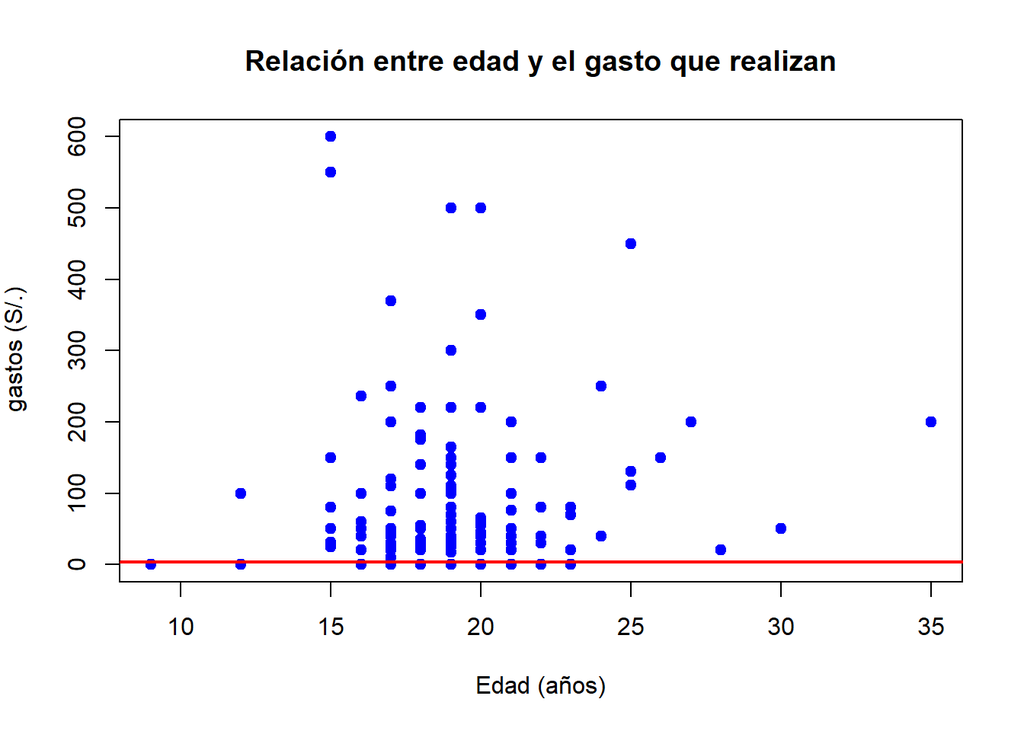

**Observaciones**

- Existen 2 valores atípicos
- En primera instancia, la edad promedio de nuestro público es de 15 a 20 años, además, son estos los que gastán más en bienes y servicios del género estudiado, pudiendo deducir que los jovenes y adolescentes son los más interesados en esta empresa.

### **Relación de los años que llevan siendo fans y el gasto en productos**

¿La personas que son fans por más años gastan más en la compra de los productos?

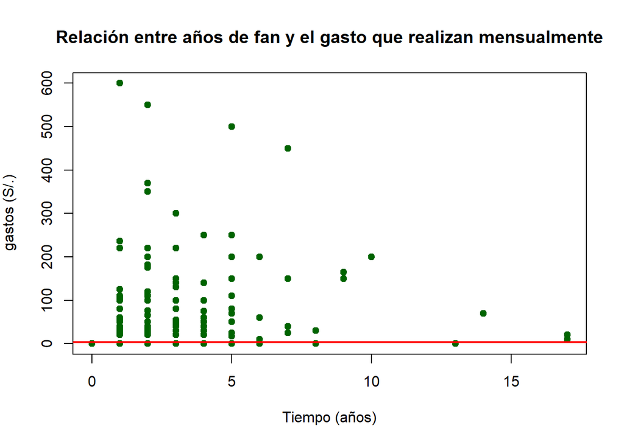

**Observaciones**

- El indice de correlación entre ambas variables es:

```
## [1] 0
```

Este valor indica una correlación baja y observando el gráfico también se aprecia lo mismo.

- No existe influencia de la cantidad de años que los seguidores llevan siendo fans sobre la cantidad de dinero que invierten mensualmente, lo que nos lleva a pensar que otra variable, como el ingreso mensual, podría influir en esta variable
- Se deduce que en lo primeros 7 años, los seguidores tienen más tendencia a gastar. Sin embargo, al pasar del tiempo, este gasto se hace cada vez menos.

  **Correlación entre el años de fan y el gasto que realizan**

```
## [1] 0
```

### **Relación entre el producto y el dinero que gastan en estos**

Analizaremos que producto es en el que gastan mayor cantidad de dinero

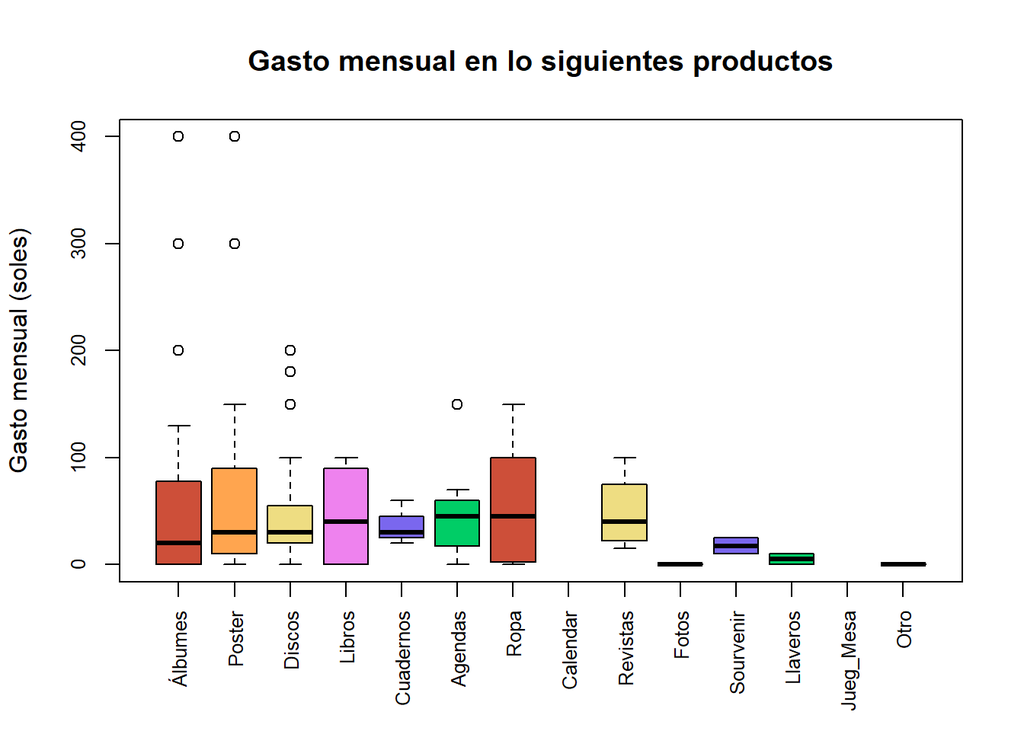

**Observaciones**

### **Relación entre el servicio y el dinero que gastan en estos**

Analizaremos que servicio es en el que gastan mayor cantidad de dinero

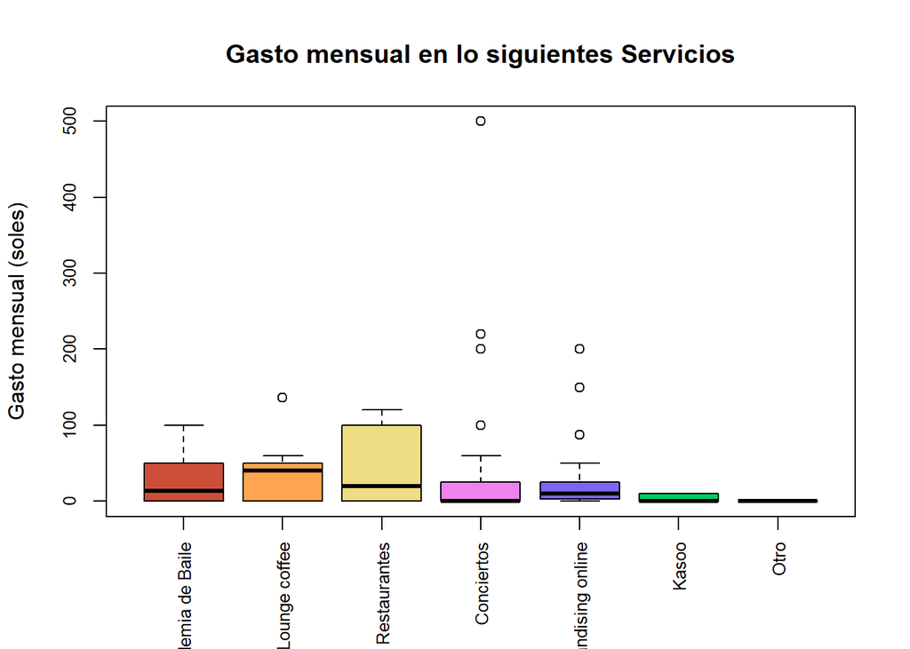

**Observaciones**

- Existen valores atípicos
- Se puede observar que el servicio de restaurante es el más pedido entre los seguidores de K-pop. Por otro lado, Kasoo (la primera tienda 100% K-pop) es el servicio menos usado.

## **Gastos mensuales y su relación con la pertenencia a un fan club**

[figure not shown]

**Observaciones**

### 5.3. Estudio de mercado sobre la propuesta de negocio: restaurante con temática k-pop

### **Dependencia a la comida china**

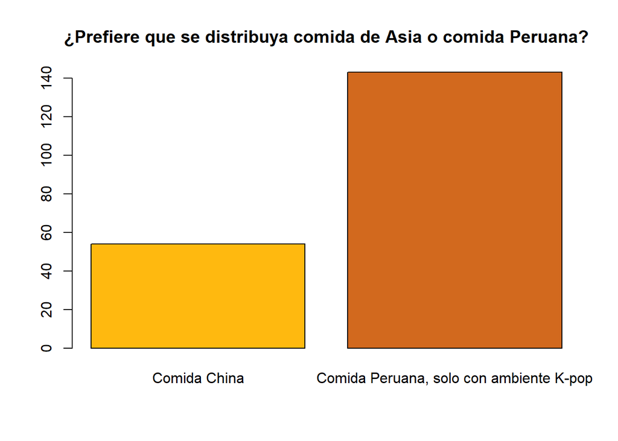

**Observaciones**

- De acuerdo al gráfico podemos deducir que más de los dos tercios de nuestra muestra prefieren que se cree un restaurante con ambiente K-pop donde se venda comida peruana.

### **Cantidad de kcal vs dieta que sigue**

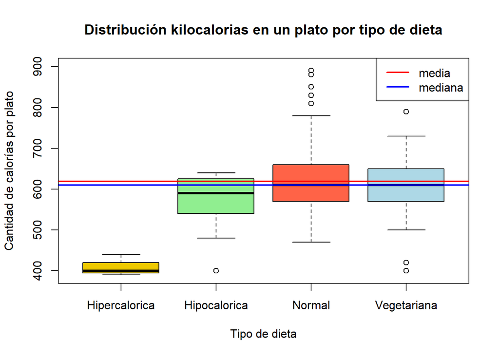

**Observaciones**

### **Relación entre el consumo mensual y relación nivel IMC**

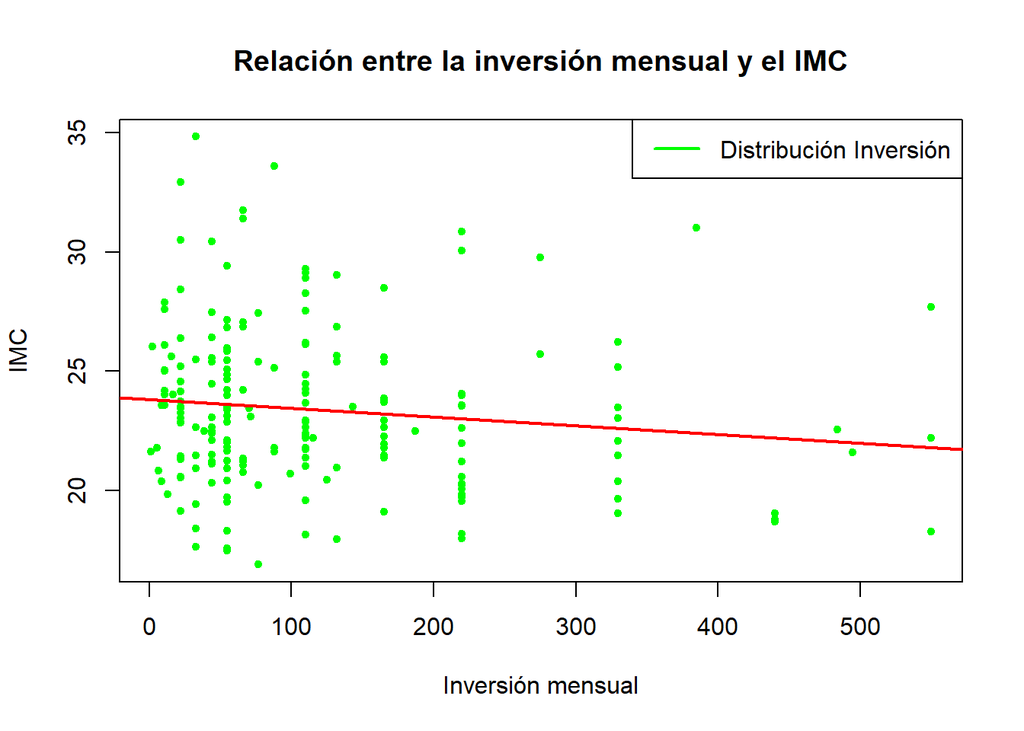

- Correlación entre el consumo mensual y el IMC de los consumidores.

```
## [1] -0.13
```

- Covarianza entre el consumo mensual y el IMC de los consumidores.

```
## [1] -48.27
```

**Observaciones**

- El IMC tiene una relación lineal decreciente con la inversión mensual.
- Se puede observar un agrupamiento de datos en la izquierda del gráfico.

### **Consumo mensual y clasificación IMC**

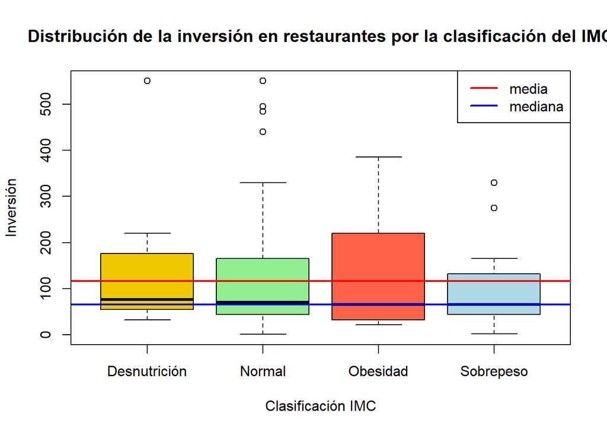

**Observaciones**

- Hay una pequeña relación entre la inversión en los restaurantes y la clasificación de IMC.
- Se puede observar datos atípicos en las clasificaciones de desnutrición, normal y sobrepeso.

### **Consumo mensual vs gasto mensual**

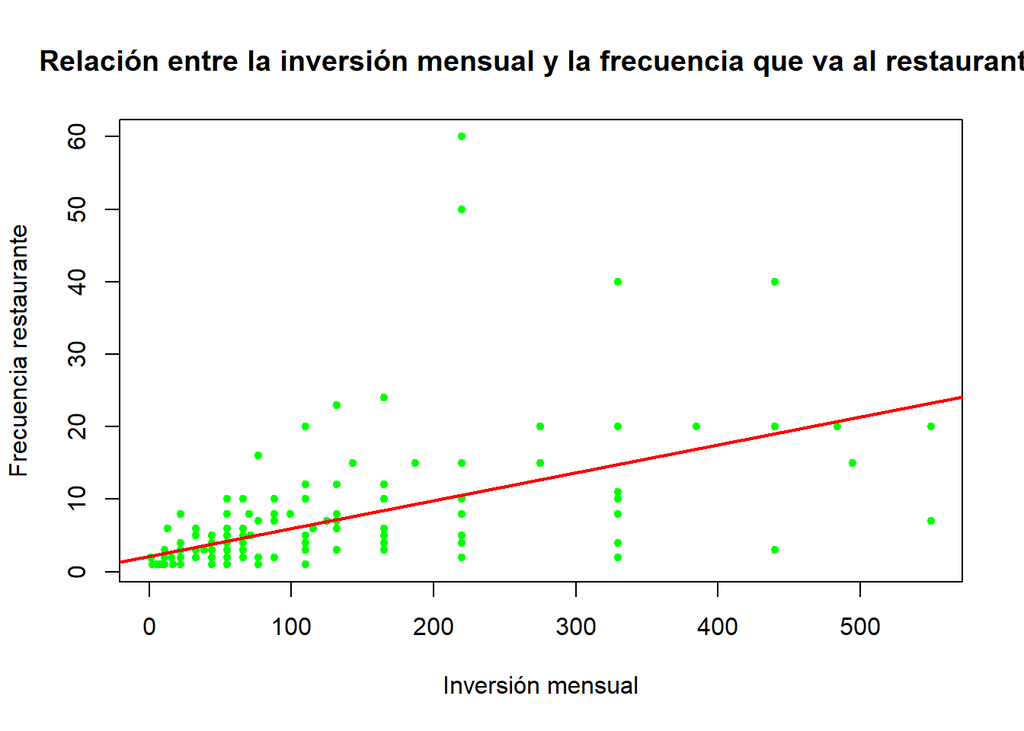

- Correlación entre el consumo mensual y la frecuencia a recurrir a un restaurante de los consumidores.

```
## [1] 0.56
```

- Covarianza entre el consumo mensual y la frecuencia a recurrir a un restaurante de los consumidores.

```
## [1] 505.88
```

**Observaciones**

- Hay una relación lineal creciente entre la inversión mensual y la frecuencia con el que acuden a un restaurante.
- Se tiene una covarianza positiva, por lo cual se considera que tienen relación estas dos variables.

### **Tipo de dieta vs clasificación del IMC**

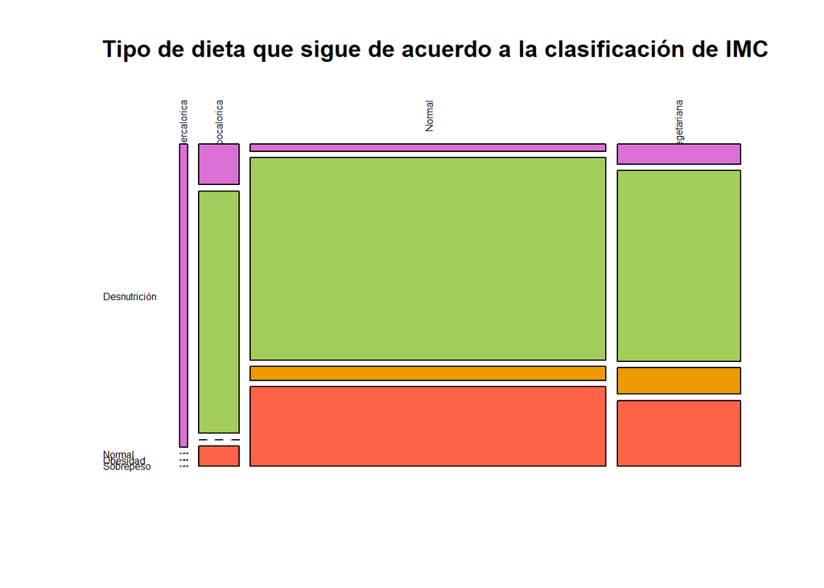

**Observaciones**

- Hay relación entre el tipo de dieta y la clasificación IMC.
- La mayor parte de los encuestados tienen el IMC dentro de lo normal, con excepción de los que tiene una dieta hipercalórico.

## 6. Variables aleatorias

Para poder analizar la distribución de las principales variables numéricas del estudio, se graficaron sus histogramas.

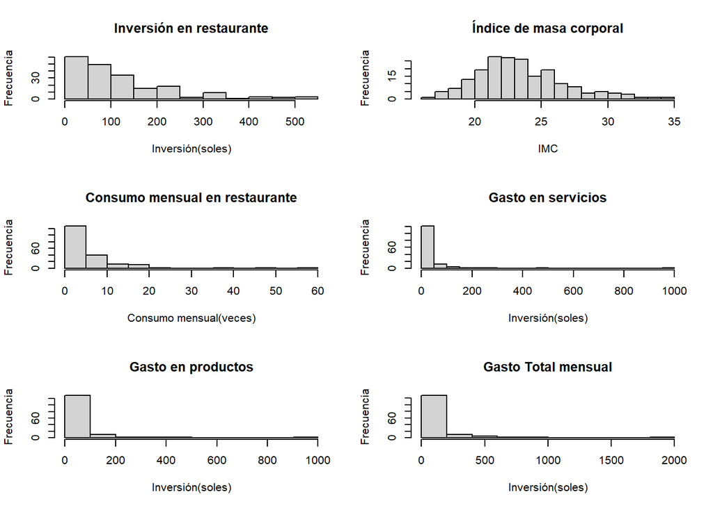

##### **Variable: Influencia del tipo de dieta en la elección del restaurante**

##### Criterios de análisis

- Éxito -> El tipo de dieta no influye en la elección de un restaurante
- Fracaso -> El tipo de dieta Sí influye en la elección de un restaurante

```
## [1] 0.6751269
```

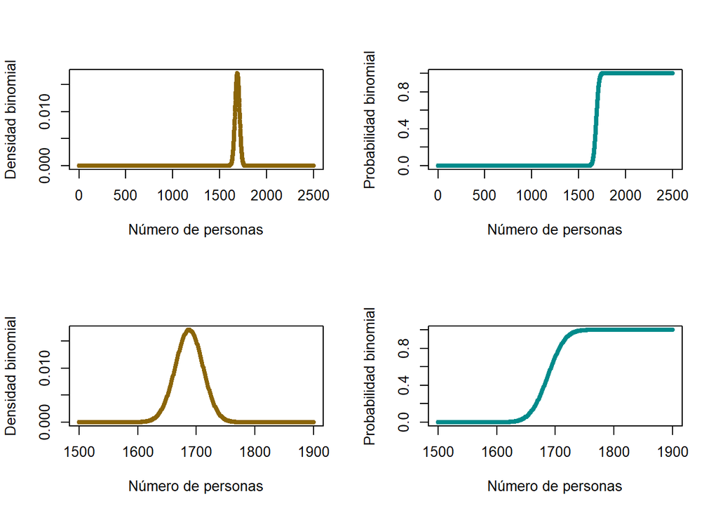

**Observaciones**

- Se espera que las personas a las que el tipo de plato en un restaurante no les importa recurran con mayor frecuencia a los restaurantes
- La mayor cantidad de personas no descarta la elección de un restaurante por el tipo de dieta que ofrezcan en sus platos. Es decir, la mayoría puede consumir o probar cualquier plato sin importar la dieta alimenticia.

### 6.2. Variables aleatorias continuas: Modelo normal

Para poder determinar que una variable aleatoria puede ser modelada por un modelo normal se tuvo el criterio de observación de su gráfico y de la similitud o cercanía de sus valores de la media, la mediana y la moda.

```
##            Indice de masa corporal Calorías en un plato (kcal)
## Media      23.39                   619.04
## Mediana    22.94                   610
## Moda       numeric,2               640
```

- Los valores que son más frecuentes o que tienen más probabilidad de aparecer están alrededor de la media.

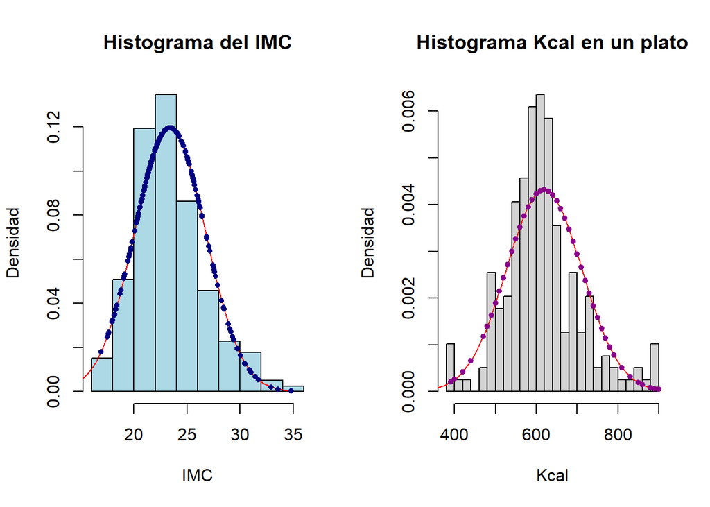

**Observaciones de la variable IMC**

- Apreciamos que la mayoría de los datos están concentrados entre 20 y 24.
- Los valores de la media, moda y mediana son parecidos, por lo cual la variable se distribuye de manera casi simétrica.

**Observaciones de la variable Kcal**

- La mayoría de los datos están centrados entre el intervalo [550,650]
- Tomando en cuenta el parecido de sus medidas de tendencia central podemos decir que sí sigue la distribución normal, pero al ver su gráfica nos damos cuenta de que existe cierta variación.